# A Cluster Analysis of Rural Pakistani Households: Socioeconomic, Climate Change, and Academic Achievement Factors

## Partitioning Clustering

Partitioning clustering is a type of clustering that divides the data into non-overlapping subsets. The most popular partitioning clustering method is K-means clustering which we will be using for this project. This is because K-means clustering can handle larger datasets.

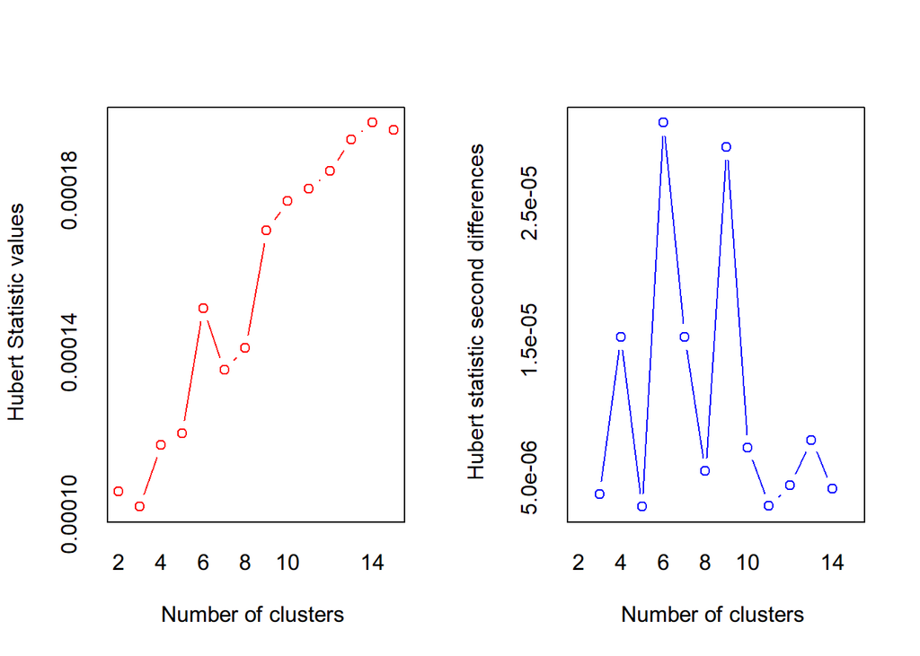

```
## *** : The Hubert index is a graphical method of determining the number of clusters.
##                 In the plot of Hubert index, we seek a significant knee that corresponds to a
##                 significant increase of the value of the measure i.e the significant peak in Hubert
##                 index second differences plot.
##
```

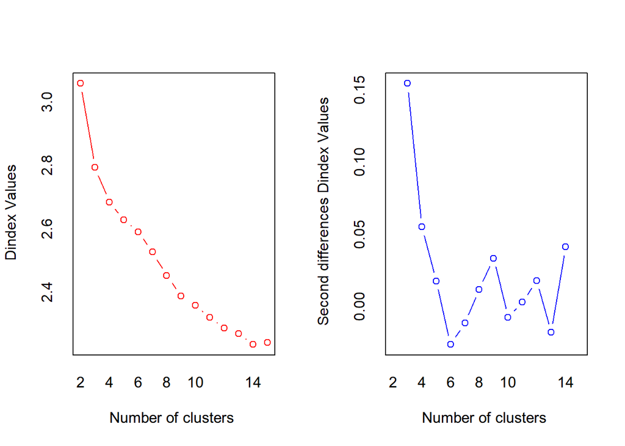

```
## *** : The D index is a graphical method of determining the number of clusters.
##                 In the plot of D index, we seek a significant knee (the significant peak in Dindex
##                 second differences plot) that corresponds to a significant increase of the value of
##                 the measure.
##
## * Among all indices:
## * 6 proposed 2 as the best number of clusters
## * 7 proposed 3 as the best number of clusters
## * 4 proposed 6 as the best number of clusters
## * 1 proposed 8 as the best number of clusters
## * 3 proposed 9 as the best number of clusters
## * 2 proposed 14 as the best number of clusters
##
##                    ***** Conclusion *****
##
## * According to the majority rule, the best number of clusters is  3
##
##
```

```r
library(ggplot2) #for plotting
library(ggdendro) #for dendrograms
library(cluster) #for clustering
library(NbClust) #for finding the optimal number of clusters

# K-Means Clustering

set.seed(1234)

num_clust_k_mean <- NbClust(aser_child_household_tib_scaled, min.nc=2, max.nc=15, method="kmeans") # 2-15 clusters, which is convention
```

```r
#According to the majority rule, the best number of clusters is  3

num_clust_k_mean$Best.nc #what are the best number of clusters according to results
```

```
##                     KL       CH Hartigan     CCC    Scott      Marriot  TrCovW
## Number_clusters 9.0000   2.0000   3.0000 14.0000    9.000 6.000000e+00       3
## Value_Index     6.1254 638.9234 237.6244 28.3102 2455.347 1.357332e+41 2166595
##                   TraceW Friedman   Rubin Cindex     DB Silhouette   Duda
## Number_clusters    3.000   3.0000  9.0000 8.0000 6.0000     2.0000 2.0000
## Value_Index     2209.674   7.4259 -0.1089 0.2385 1.6455     0.2362 0.9945
##                 PseudoT2  Beale Ratkowsky    Ball PtBiserial Frey McClain
## Number_clusters   2.0000 2.0000    3.0000    3.00     6.0000    1  2.0000
## Value_Index       9.6952 0.0495    0.2965 5482.96     0.5106   NA  0.5944
##                   Dunn Hubert SDindex Dindex    SDbw
## Number_clusters 6.0000      0  3.0000      0 14.0000
## Value_Index     0.0446      0  1.6495      0  0.6921
```

```r
#show this in a histogram...
hist(num_clust_k_mean$Best.nc[1,],breaks = 15)  #3 seems to be the best number of clusters

# Final cluster
set.seed(1234)

final_km <- kmeans(aser_child_household_tib_scaled, 3, nstart=25)

final_km$size #how many observations in each cluster?
```

[output not shown]

```
## [1]  691  714 1049
```

```r
final_km$centers # coordinates of the final cluster centers (the final locations of the cluster centroids)
```

```
##   HouseholdCounter EarningMembers         Car MotorCycle TravelTime
## 1      -0.10305663     -0.3604706 -0.46871932 -0.4213939 -0.2193955
## 2      -0.01361321     -0.0496328 -0.06301049 -0.1056574 -0.1552914
## 3       0.07715154      0.2712326  0.35164398  0.3494972  0.2502196
##   ClimateChange FloodImpacted EarningImpacted PsychologicalImpacted
## 1   -0.53022885    -1.3151929      -0.8975102            -1.2540498
## 2    0.08741612     0.4892677       0.2456864             0.4800671
## 3    0.28977410     0.5333280       0.4239842             0.4993141
##   SchoolingAffected LocalLangReadingLevel ArithmeticLevel EnglishReadingLevel
## 1        -1.2375145           -0.04924437     -0.09470771          -0.1672107
## 2         0.5171527           -1.00847826     -0.97659268          -0.9689060
## 3         0.4631797            0.71885733      0.72710220           0.7696297
```

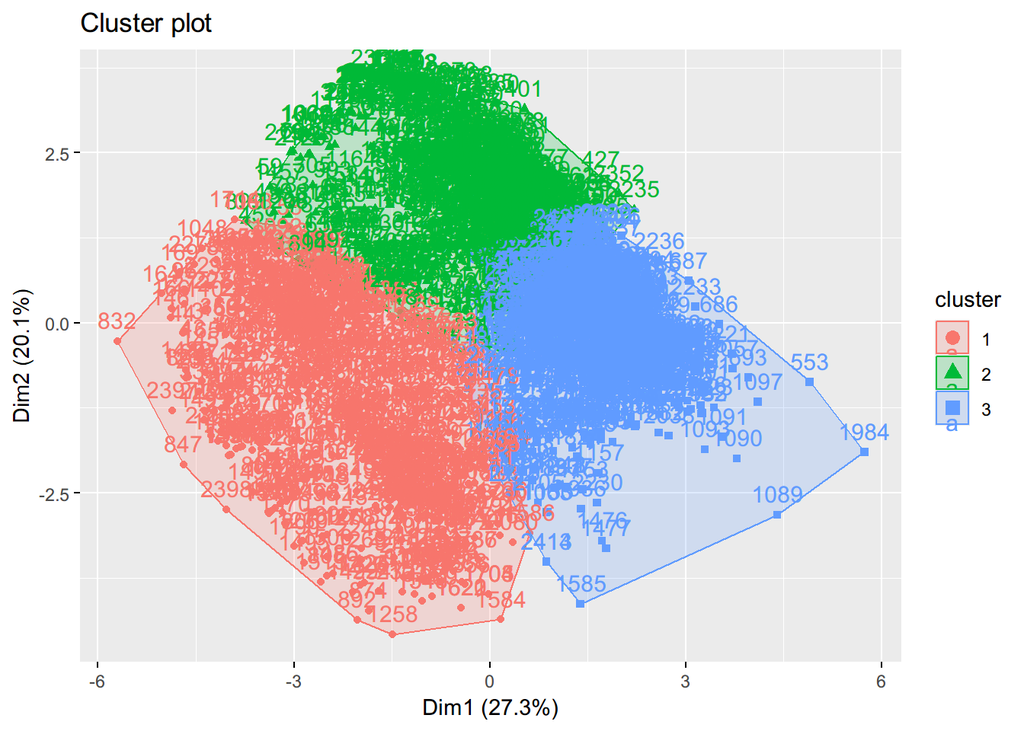

```r
#get a cluster plot

fviz_cluster(final_km, data=aser_child_household_tib_scaled)
```

## Analyzing The Clusters

The next step is to analyze the clusters based on the mean values of the variables in each cluster. This will help us understand the characteristics of each cluster and how they differ from each other. Note that while our original dataset contains a mix of continuous and ordinal variables, our interpretation of the clusters will be based on the mean values of these variables that will still be informative.

We begin by adding the cluster assignment to the original dataset.

```r
# Adding the cluster assignment to the original dataset

final_km_clusters <- final_km$cluster

final_km_clusters <- as.data.frame(final_km_clusters) %>%
  rename(cluster = final_km_clusters)

aser_child_household_tib$cluster <- final_km$cluster
```

Creating a new column to see the sample size of each cluster. We find the following.

| Cluster | Count |
| --- | --- |
| Cluster 1 | 691 |
| Cluster 2 | 714 |
| Cluster 3 | 1049 |

Across all the variables, we are summarizing the characteristics of variables by mean only.

```r
# Analyzing the clusters based on the mean values of the variables in each cluster

aser_child_household_tib_test <- aser_child_household_tib %>%
  group_by(cluster) %>%
  mutate(sample_size = n()) %>%
  summarise(across(-c(IsInternetAvailable, InstitutionType, sample_size), ~ mean(.)),
              sample_size = mean(sample_size))

# Printing the output of the first analysis tibble.

print(aser_child_household_tib_test)
```

```
## # A tibble: 3 × 16
##   cluster       Id HouseholdCounter EarningMembers   Car MotorCycle TravelTime
##     <int>    <dbl>            <dbl>          <dbl> <dbl>      <dbl>      <dbl>
## 1       1 1561810.             9.90          0.711 0.346      0.660       1.34
## 2       2 1567553.            10.4           1.04  0.679      0.835       1.38
## 3       3 1567750.            11.0           1.38  1.02       1.09        1.66
## # ℹ 9 more variables: ClimateChange <dbl>, FloodImpacted <dbl>,
## #   EarningImpacted <dbl>, PsychologicalImpacted <dbl>,
## #   SchoolingAffected <dbl>, LocalLangReadingLevel <dbl>,
## #   ArithmeticLevel <dbl>, EnglishReadingLevel <dbl>, sample_size <dbl>
```

Making a second tibble to provide results of cluster based count and proportion for our grouping variables: IsInternetAvailable and InstitutionType to see how they differentiate across the three clusters.

```r
# Making a second tibble to provide results of cluster based count and proportion for our grouping variables: IsInternetAvailable and InstitutionType to see how they differentiate across the three clusters.

aser_child_household_tib_test_2 <- aser_child_household_tib %>%
  mutate(IsInternetAvailable = factor(IsInternetAvailable, levels = c(0, 1), labels = c("No", "Yes")),
         InstitutionType = factor(InstitutionType, levels = c(1, 2, 3, 4), labels = c("Government", "Private", "Madrassah", "NFE/Other"))) %>%
  group_by(cluster, IsInternetAvailable, InstitutionType) %>%
  summarize(count = n()) %>%
  mutate(proportion = count / sum(count)) %>%
  ungroup()
print(aser_child_household_tib_test_2)
```

```
## # A tibble: 18 × 5
##    cluster IsInternetAvailable InstitutionType count proportion
##      <int> <fct>               <fct>           <int>      <dbl>
##  1       1 No                  Government        429    0.796
##  2       1 No                  Private            74    0.137
##  3       1 No                  NFE/Other          36    0.0668
##  4       1 Yes                 Government         71    0.467
##  5       1 Yes                 Private            81    0.533
##  6       2 No                  Government        360    0.721
##  7       2 No                  Private           132    0.265
##  8       2 No                  Madrassah           7    0.0140
##  9       2 Yes                 Government         78    0.363
## 10       2 Yes                 Private           135    0.628
## 11       2 Yes                 Madrassah           2    0.00930
## 12       3 No                  Government        368    0.626
## 13       3 No                  Private           204    0.347
## 14       3 No                  Madrassah          11    0.0187
## 15       3 No                  NFE/Other           5    0.00850
## 16       3 Yes                 Government        218    0.473
## 17       3 Yes                 Private           239    0.518
## 18       3 Yes                 Madrassah           4    0.00868
```

## Interpretation of Clusters

The clusters are interpreted based on the mean values of the variables in each cluster.

Variables such as **Climate Change** (whether the household reports being informed about climate change or not) and **Schooling Affected** (whether the household reports schooling being affected during the survey year due to environmental factors) require inverse interpretation. For example, a **higher** mean score for ‘Climate Change’ within a cluster indicates lower reported understanding of climate-related challenges, while a **lower** score for ‘Schooling Affected’ corresponds to a higher extent of educational disruption.

For **FloodImpacted** (whether the household reports being impacted during the 2022-23 floods and to what extent), **lower** mean scores indicate **significant** impact from natural disasters and vice versa.

For **PsychologicalImpact** (whether the household reports being psychologically impacted during the 2022-23 floods and to what extent), **lower** mean scores indicate **substantial** psychological impact from natural disasters and vice versa.

The variables related to academic achievement: **LocalLangReadingLevel**, **ArithmeticLevel**, **EnglishReadingLevel** can be interpreted as lower mean score indicating low proficiency and higher mean score indicating higher proficiency.

The variables related to **HouseholdCounter**, **EarningMembers**, **Car**, **Motorcycle**, and **TravelTime** are continuous and hence can be interpreted at face value.

#### Cluster 1: Low Socioeconomic Status, Climate-Conscious, Significantly Impacted, Moderate Academic Achievement

Cluster 1 represents a group that is aware of and significantly affected by climate change, particularly floods. They experience educational disruption and psychological impacts. Despite these challenges, they demonstrate moderate academic achievement. This group might have limited resources, as indicated by the lower number of earning members and car ownership. Their relatively shorter travel time to school could be a contributing factor to their moderate academic performance despite the climate-related challenges.

#### Cluster 2: Moderate Socioeconomic Status, Lower Climate Change Awareness, Moderately Impacted, Low Academic Achievement

Cluster 2 exhibits lower awareness of climate change and experiences a lower impact from floods compared to Cluster 1. They also report less disruption to earnings, education, and psychological well-being due to environmental factors. However, this cluster has the lowest academic achievement across all three subjects. This group might have slightly more resources than Cluster 1, but their academic performance is notably poor.

#### Cluster 3: High Socioeconomic Status, Lower Climate Change Awareness, Moderately Impacted, High Academic Achievement

Cluster 3 represents a group with lower reported understanding of climate change but also experiences a lower impact from floods and other environmental factors compared to Cluster 1. They have the highest academic achievement across all subjects, despite having the longest travel time to school. This cluster appears to be the most well-off in terms of household size, earning members, and asset ownership (cars and motorcycles).

## Visualizations of Clusters

### Internet Availability Across the Clusters (Frequency)

The following bar plot shows the distribution of households with and without internet availability across the three clusters. Cluster 3 has the highest proportion of households with internet access, followed by Cluster 2 and Cluster 1. This suggests that internet access is predominant in households with higher socioeconomic status and there may be an underlying pattern resulting in higher academic achievement for the students in the said households compared to the households with no access.

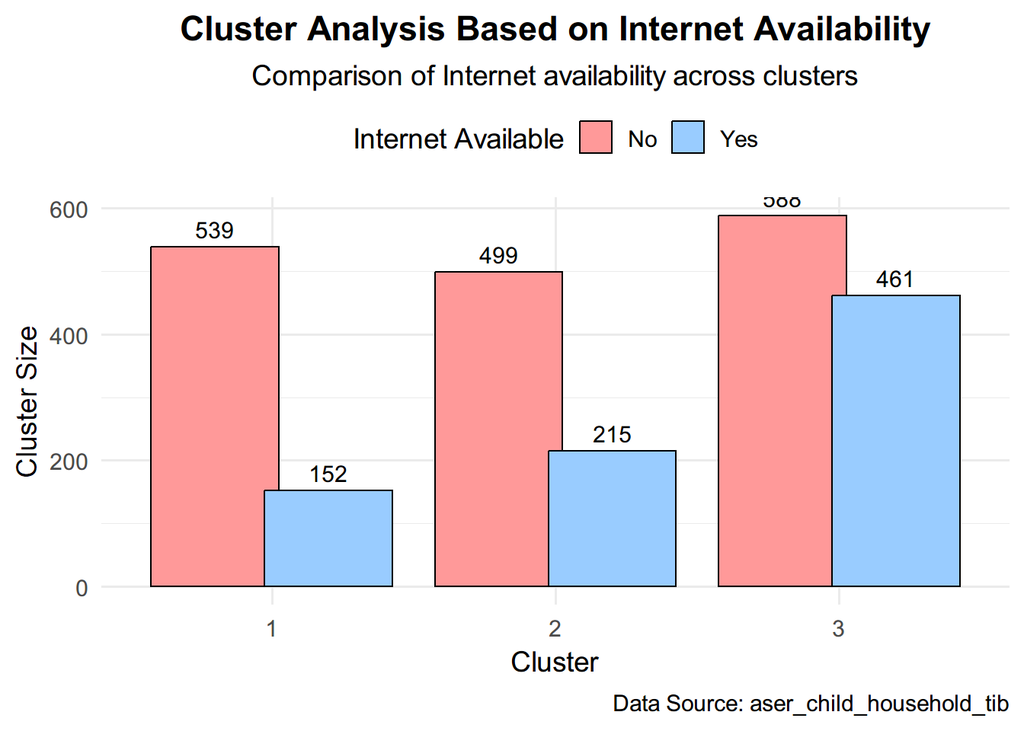

```r
# Analyzing The Clusters Based On IsInternetAvailable

ggplot(aser_child_household_tib %>%
         group_by(cluster, IsInternetAvailable) %>%
         summarise(sample_size = n()),
       aes(x = factor(cluster), y = sample_size, fill = factor(IsInternetAvailable))) +
  geom_bar(stat = "identity", position = position_dodge(width = 0.8), color = "black") +
  scale_fill_manual(values = c("0" = "#FF9999", "1" = "#99CCFF"),
                    name = "Internet Available",
                    labels = c("No", "Yes")) +
  labs(
    title = "Cluster Analysis Based on Internet Availability",
    subtitle = "Comparison of Internet availability across clusters",
    x = "Cluster",
    y = "Cluster Size",
    caption = "Data Source: aser_child_household_tib"
  ) +
  theme_minimal(base_size = 14) +
  theme(
    plot.title = element_text(face = "bold", hjust = 0.5),
    plot.subtitle = element_text(hjust = 0.5),
    legend.position = "top"
  ) +
  geom_text(aes(label = sample_size),
            position = position_dodge(width = 0.8),
            vjust = -0.5, size = 4, color = "black")
```

### Types of School Across the Clusters (Frequency)

The following bar plot shows the distribution of different types of institutions that students are enrolled in across the three clusters. Cluster 3 has the highest proportion of students enrolled in private institutions, followed by Cluster 2 and Cluster 1. This suggests that students from households with higher socioeconomic status are more likely to attend private schools, which may contribute to their higher academic achievement compared to students in government or other types of institutions.

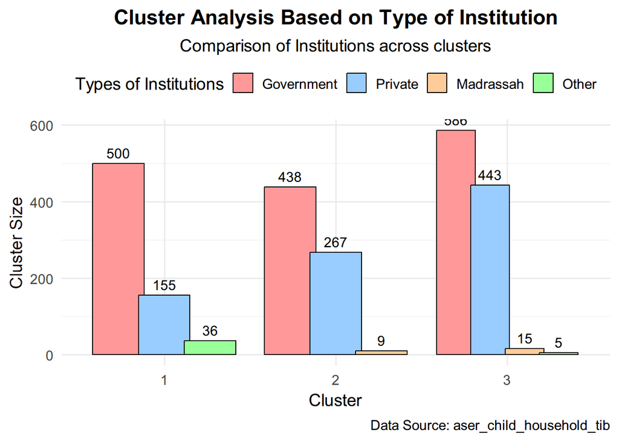

```r
# Analyzing The Clusters Based On InstitutionType

ggplot(aser_child_household_tib %>%
         group_by(cluster, InstitutionType) %>%
         summarise(sample_size = n()),
       aes(x = factor(cluster), y = sample_size, fill = factor(InstitutionType))) +
  geom_bar(stat = "identity", position = position_dodge(width = 0.8), color = "black") +
  scale_fill_manual(values = c("1" = "#FF9999", "2" = "#99CCFF", "3" = "#FFCC99", "4" = "#99FF99"),
                    name = "Types of Institutions",
                    labels = c("Government", "Private", "Madrassah", "Other")) +
  labs(
    title = "Cluster Analysis Based on Type of Institution",
    subtitle = "Comparison of Institutions across clusters",
    x = "Cluster",
    y = "Cluster Size",
    caption = "Data Source: aser_child_household_tib"
  ) +
  theme_minimal(base_size = 14) +
  theme(
    plot.title = element_text(face = "bold", hjust = 0.5),
    plot.subtitle = element_text(hjust = 0.5),
    legend.position = "top"
  ) +
  geom_text(aes(label = sample_size),
            position = position_dodge(width = 0.8),
            vjust = -0.5, size = 4, color = "black")
```

### Internet Availability Across the Clusters (Percentage)

```r
# Calculate proportions within each cluster
proportions_df <- aser_child_household_tib %>%
  group_by(cluster, IsInternetAvailable) %>%
  summarise(sample_size = n()) %>%
  group_by(cluster) %>%
  mutate(proportion = (sample_size / sum(sample_size)) * 100)
```

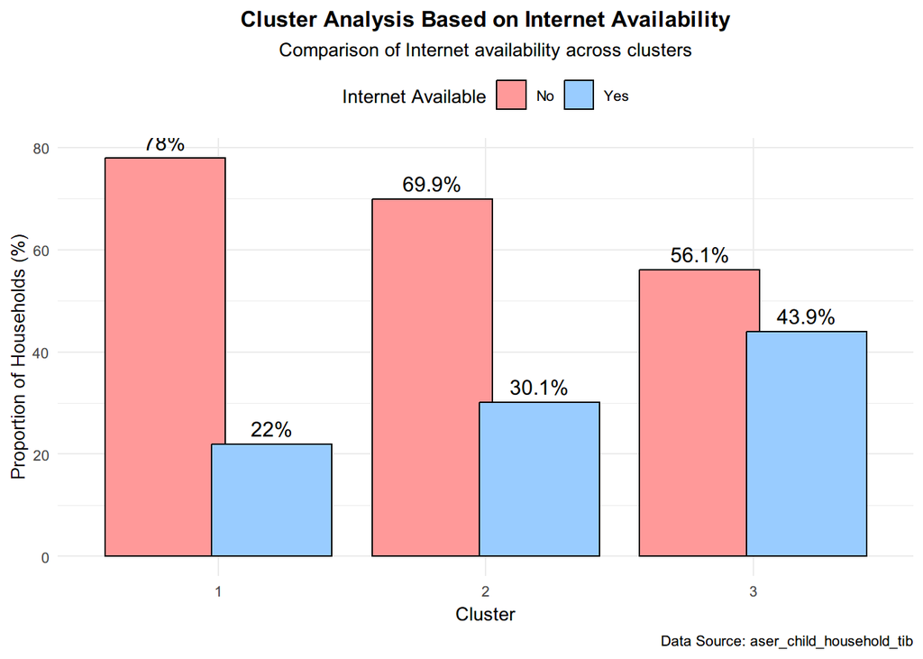

```r
# Plot the proportions
ggplot(proportions_df,
       aes(x = factor(cluster), y = proportion, fill = factor(IsInternetAvailable))) +
  geom_bar(stat = "identity", position = position_dodge(width = 0.8), color = "black") +
  scale_fill_manual(values = c("0" = "#FF9999", "1" = "#99CCFF"),
                       name = "Internet Available",
                       labels = c("No", "Yes")) +
  labs(
    title = "Cluster Analysis Based on Internet Availability",
    subtitle = "Comparison of Internet availability across clusters",
    x = "Cluster",
    y = "Proportion of Households (%)",
    caption = "Data Source: aser_child_household_tib"
  ) +
  theme_minimal(base_size = 10) +
  theme(
    plot.title = element_text(face = "bold", hjust = 0.5),
    plot.subtitle = element_text(hjust = 0.5),
    legend.position = "top"
  ) +
  geom_text(aes(label = paste0(round(proportion, 1), "%")),
              position = position_dodge(width = 0.8),
              vjust = -0.5, size = 4, color = "black")
```

### Types of School Across the Clusters (Percentage)

```r
# Calculate proportions within each cluster
proportions_df_in <- aser_child_household_tib %>%
  group_by(cluster, InstitutionType) %>%
  summarise(sample_size = n()) %>%
  group_by(cluster) %>%
  mutate(proportion = (sample_size / sum(sample_size)) * 100)
```

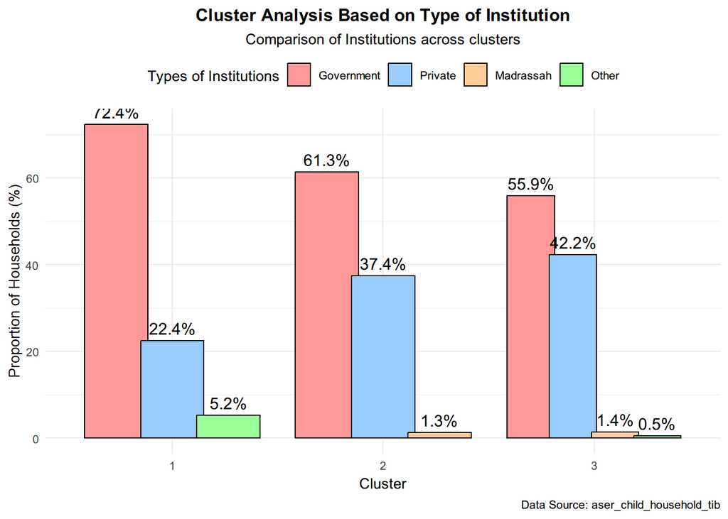

```r
# Plot the proportions
ggplot(proportions_df_in,
       aes(x = factor(cluster), y = proportion, fill = factor(InstitutionType))) +
  geom_bar(stat = "identity", position = position_dodge(width = 0.8), color = "black") +
  scale_fill_manual(values = c("1" = "#FF9999", "2" = "#99CCFF", "3" = "#FFCC99", "4" = "#99FF99"),
                       name = "Types of Institutions",
                       labels = c("Government", "Private", "Madrassah", "Other")) +
  labs(
    title = "Cluster Analysis Based on Type of Institution",
    subtitle = "Comparison of Institutions across clusters",
    x = "Cluster",
    y = "Proportion of Households (%)",
    caption = "Data Source: aser_child_household_tib"
  ) +
  theme_minimal(base_size = 10) +
  theme(
    plot.title = element_text(face = "bold", hjust = 0.5),
    plot.subtitle = element_text(hjust = 0.5),
    legend.position = "top"
  ) +
  geom_text(aes(label = paste0(round(proportion, 1), "%")),
              position = position_dodge(width = 0.8),
              vjust = -0.5, size = 4, color = "black")
```

## Clustering Rural Households by Internet Access and Institution Type

The following plot shows the distribution of different types of institutions that students are enrolled in across the three clusters, with separate panels for households with and without internet access. This visualization provides a comprehensive view of how internet availability and institution types are distributed across the clusters.

As we can see, households with internet access are more likely to have students enrolled in private institutions, followed by government institutions. In contrast, households without internet access have a higher proportion of students enrolled in government institutions, followed by private institutions.

This suggests that internet access may be associated with higher socioeconomic status, leading to a higher likelihood of students attending private schools leading to better academic outcomes.

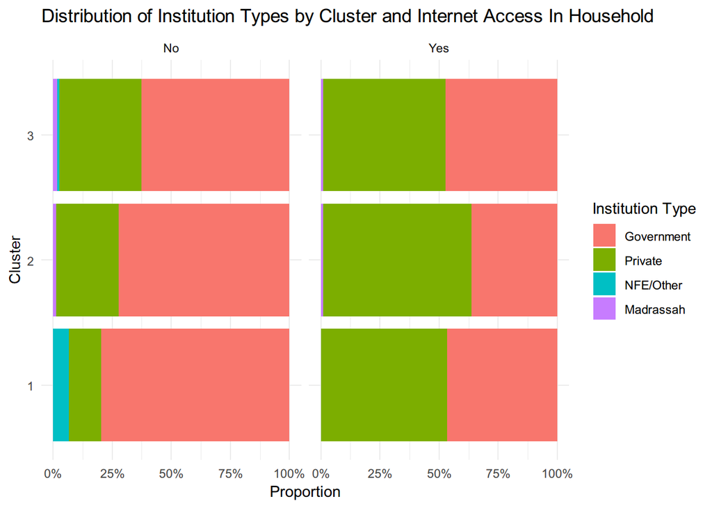

```r
ggplot(aser_child_household_tib_test_2, aes(x = factor(cluster), y = proportion, fill = reorder(InstitutionType, -proportion))) +
  geom_bar(stat = "identity") +
  coord_flip() + # Flip the x and y axes for improved readability
  facet_wrap(~IsInternetAvailable) + # Create separate panels for "Yes" and "No" internet access
  labs(title = "Distribution of Institution Types by Cluster and Internet Access In Household",
       x = "Cluster",
       y = "Proportion",
       fill = "Institution Type") +
  theme_minimal() +
  scale_y_continuous(labels = scales::percent_format()) # Format y-axis as percentages
```

## Conclusion

This project identified three distinct rural household profiles in Pakistan based on socioeconomic factors, climate change impacts, and academic achievements of the students belonging to those surveyed households.

- **Cluster 1** represents households with low socioeconomic status, high climate change awareness, significant impact from floods, moderate academic achievement, and limited resources.
- **Cluster 2** represents households with moderate socioeconomic status, lower climate change awareness, moderate impact from floods, low academic achievement, and slightly more resources than Cluster 1.
- **Cluster 3** represents households with high socioeconomic status, lower climate change awareness, moderate impact from floods, high academic achievement, and the most resources among the three clusters.

The analysis also revealed that across the three clusters households with internet access are more likely to have students enrolled in private institutions, while households without internet access have a higher proportion of students enrolled in government institutions. This suggests that internet access may be associated with higher socioeconomic status, leading to better academic outcomes for students attending private schools.

Another way to interpret these results would be to consider the specific case of Cluster 3, which shows resilience to climate change impact despite showing low awareness about climate change compared to Cluster 1. Yet, due to their high socioeconomic status through Internet and/or digital access to communication and information, they are able to provide better educational opportunities for their children, leading to higher academic achievement.

## Discussion and Limitations

The findings of this project have certain limitations beginning with the nature of the data itself. The data is based on self-reported responses from households, which may be subject to recall bias or social desirability bias. Additionally, the survey was conducted in rural areas of Pakistan, which, despite the label, is not a homogeneous group. There may be significant variations within rural areas that are not captured by the data.

Furthermore, this study did not conduct analysis of variance (ANOVA) or other statistical tests to determine the statistical significance of the observed differences in internet access and academic achievement across the clusters. Therefore, the findings should be interpreted as descriptive and exploratory rather than inferential.

Furthermore, the clustering analysis is based on a limited set of variables, which may not fully capture the complexity of rural households in Pakistan.